# Risk Factor Analysis

## Outcome Variable

**Outcome Variable:** ever_wasted

## Predictor Variables

**Intervention Variable:** nrooms

**Adjustment Set:**

unadjusted

## Stratifying Variables

The analysis was stratified on these variable(s):

- agecat
- studyid
- country

## Data Summary

| agecat | studyid | country | nrooms | ever_wasted | n_cell | n |
| --- | --- | --- | --- | --- | --- | --- |
| 0-24 months | ki0047075b-MAL-ED | BANGLADESH | 1 | 0 | 92 | 242 |
| 0-24 months | ki0047075b-MAL-ED | BANGLADESH | 1 | 1 | 60 | 242 |
| 0-24 months | ki0047075b-MAL-ED | BANGLADESH | 2 | 0 | 37 | 242 |
| 0-24 months | ki0047075b-MAL-ED | BANGLADESH | 2 | 1 | 13 | 242 |
| 0-24 months | ki0047075b-MAL-ED | BANGLADESH | 3 | 0 | 20 | 242 |
| 0-24 months | ki0047075b-MAL-ED | BANGLADESH | 3 | 1 | 8 | 242 |
| 0-24 months | ki0047075b-MAL-ED | BANGLADESH | 4+ | 0 | 9 | 242 |
| 0-24 months | ki0047075b-MAL-ED | BANGLADESH | 4+ | 1 | 3 | 242 |
| 0-24 months | ki0047075b-MAL-ED | BRAZIL | 1 | 0 | 4 | 210 |
| 0-24 months | ki0047075b-MAL-ED | BRAZIL | 1 | 1 | 0 | 210 |
| 0-24 months | ki0047075b-MAL-ED | BRAZIL | 2 | 0 | 18 | 210 |
| 0-24 months | ki0047075b-MAL-ED | BRAZIL | 2 | 1 | 2 | 210 |
| 0-24 months | ki0047075b-MAL-ED | BRAZIL | 3 | 0 | 55 | 210 |
| 0-24 months | ki0047075b-MAL-ED | BRAZIL | 3 | 1 | 4 | 210 |
| 0-24 months | ki0047075b-MAL-ED | BRAZIL | 4+ | 0 | 114 | 210 |
| 0-24 months | ki0047075b-MAL-ED | BRAZIL | 4+ | 1 | 13 | 210 |
| 0-24 months | ki0047075b-MAL-ED | INDIA | 1 | 0 | 43 | 235 |
| 0-24 months | ki0047075b-MAL-ED | INDIA | 1 | 1 | 41 | 235 |
| 0-24 months | ki0047075b-MAL-ED | INDIA | 2 | 0 | 38 | 235 |
| 0-24 months | ki0047075b-MAL-ED | INDIA | 2 | 1 | 40 | 235 |
| 0-24 months | ki0047075b-MAL-ED | INDIA | 3 | 0 | 25 | 235 |
| 0-24 months | ki0047075b-MAL-ED | INDIA | 3 | 1 | 23 | 235 |
| 0-24 months | ki0047075b-MAL-ED | INDIA | 4+ | 0 | 16 | 235 |
| 0-24 months | ki0047075b-MAL-ED | INDIA | 4+ | 1 | 9 | 235 |
| 0-24 months | ki0047075b-MAL-ED | NEPAL | 1 | 0 | 31 | 236 |
| 0-24 months | ki0047075b-MAL-ED | NEPAL | 1 | 1 | 21 | 236 |
| 0-24 months | ki0047075b-MAL-ED | NEPAL | 2 | 0 | 26 | 236 |
| 0-24 months | ki0047075b-MAL-ED | NEPAL | 2 | 1 | 5 | 236 |
| 0-24 months | ki0047075b-MAL-ED | NEPAL | 3 | 0 | 16 | 236 |
| 0-24 months | ki0047075b-MAL-ED | NEPAL | 3 | 1 | 6 | 236 |

[output cut: 354 more lines]

The following strata were considered:

- agecat: 0-24 months, studyid: ki0047075b-MAL-ED, country: BANGLADESH
- agecat: 0-24 months, studyid: ki0047075b-MAL-ED, country: BRAZIL
- agecat: 0-24 months, studyid: ki0047075b-MAL-ED, country: INDIA
- agecat: 0-24 months, studyid: ki0047075b-MAL-ED, country: NEPAL
- agecat: 0-24 months, studyid: ki0047075b-MAL-ED, country: PERU
- agecat: 0-24 months, studyid: ki0047075b-MAL-ED, country: SOUTH AFRICA
- agecat: 0-24 months, studyid: ki0047075b-MAL-ED, country: TANZANIA, UNITED REPUBLIC OF
- agecat: 0-24 months, studyid: ki1000108-CMC-V-BCS-2002, country: INDIA
- agecat: 0-24 months, studyid: ki1000108-IRC, country: INDIA
- agecat: 0-24 months, studyid: ki1017093b-PROVIDE, country: BANGLADESH
- agecat: 0-24 months, studyid: ki1017093c-NIH-Crypto, country: BANGLADESH
- agecat: 0-24 months, studyid: ki1113344-GMS-Nepal, country: NEPAL
- agecat: 0-24 months, studyid: ki1114097-CONTENT, country: PERU
- agecat: 0-24 months, studyid: ki1135781-COHORTS, country: INDIA
- agecat: 0-24 months, studyid: kiGH5241-JiVitA-3, country: BANGLADESH
- agecat: 0-24 months, studyid: kiGH5241-JiVitA-4, country: BANGLADESH
- agecat: 0-6 months, studyid: ki0047075b-MAL-ED, country: BANGLADESH
- agecat: 0-6 months, studyid: ki0047075b-MAL-ED, country: BRAZIL
- agecat: 0-6 months, studyid: ki0047075b-MAL-ED, country: INDIA
- agecat: 0-6 months, studyid: ki0047075b-MAL-ED, country: NEPAL
- agecat: 0-6 months, studyid: ki0047075b-MAL-ED, country: PERU
- agecat: 0-6 months, studyid: ki0047075b-MAL-ED, country: SOUTH AFRICA
- agecat: 0-6 months, studyid: ki0047075b-MAL-ED, country: TANZANIA, UNITED REPUBLIC OF
- agecat: 0-6 months, studyid: ki1000108-CMC-V-BCS-2002, country: INDIA
- agecat: 0-6 months, studyid: ki1000108-IRC, country: INDIA
- agecat: 0-6 months, studyid: ki1017093b-PROVIDE, country: BANGLADESH
- agecat: 0-6 months, studyid: ki1017093c-NIH-Crypto, country: BANGLADESH
- agecat: 0-6 months, studyid: ki1113344-GMS-Nepal, country: NEPAL
- agecat: 0-6 months, studyid: ki1114097-CONTENT, country: PERU
- agecat: 0-6 months, studyid: ki1135781-COHORTS, country: INDIA
- agecat: 0-6 months, studyid: kiGH5241-JiVitA-3, country: BANGLADESH
- agecat: 0-6 months, studyid: kiGH5241-JiVitA-4, country: BANGLADESH
- agecat: 6-24 months, studyid: ki0047075b-MAL-ED, country: BANGLADESH
- agecat: 6-24 months, studyid: ki0047075b-MAL-ED, country: BRAZIL
- agecat: 6-24 months, studyid: ki0047075b-MAL-ED, country: INDIA
- agecat: 6-24 months, studyid: ki0047075b-MAL-ED, country: NEPAL
- agecat: 6-24 months, studyid: ki0047075b-MAL-ED, country: PERU
- agecat: 6-24 months, studyid: ki0047075b-MAL-ED, country: SOUTH AFRICA
- agecat: 6-24 months, studyid: ki0047075b-MAL-ED, country: TANZANIA, UNITED REPUBLIC OF
- agecat: 6-24 months, studyid: ki1000108-CMC-V-BCS-2002, country: INDIA
- agecat: 6-24 months, studyid: ki1000108-IRC, country: INDIA
- agecat: 6-24 months, studyid: ki1017093b-PROVIDE, country: BANGLADESH
- agecat: 6-24 months, studyid: ki1017093c-NIH-Crypto, country: BANGLADESH
- agecat: 6-24 months, studyid: ki1113344-GMS-Nepal, country: NEPAL
- agecat: 6-24 months, studyid: ki1114097-CONTENT, country: PERU
- agecat: 6-24 months, studyid: ki1135781-COHORTS, country: INDIA
- agecat: 6-24 months, studyid: kiGH5241-JiVitA-3, country: BANGLADESH
- agecat: 6-24 months, studyid: kiGH5241-JiVitA-4, country: BANGLADESH

### Dropped Strata

Some strata were dropped due to rare outcomes:

- agecat: 0-24 months, studyid: ki0047075b-MAL-ED, country: BANGLADESH
- agecat: 0-24 months, studyid: ki0047075b-MAL-ED, country: BRAZIL
- agecat: 0-24 months, studyid: ki0047075b-MAL-ED, country: PERU
- agecat: 0-24 months, studyid: ki0047075b-MAL-ED, country: SOUTH AFRICA
- agecat: 0-24 months, studyid: ki0047075b-MAL-ED, country: TANZANIA, UNITED REPUBLIC OF
- agecat: 0-24 months, studyid: ki1114097-CONTENT, country: PERU
- agecat: 0-6 months, studyid: ki0047075b-MAL-ED, country: BANGLADESH
- agecat: 0-6 months, studyid: ki0047075b-MAL-ED, country: BRAZIL
- agecat: 0-6 months, studyid: ki0047075b-MAL-ED, country: NEPAL
- agecat: 0-6 months, studyid: ki0047075b-MAL-ED, country: PERU
- agecat: 0-6 months, studyid: ki0047075b-MAL-ED, country: SOUTH AFRICA
- agecat: 0-6 months, studyid: ki0047075b-MAL-ED, country: TANZANIA, UNITED REPUBLIC OF
- agecat: 0-6 months, studyid: ki1000108-CMC-V-BCS-2002, country: INDIA
- agecat: 0-6 months, studyid: ki1114097-CONTENT, country: PERU
- agecat: 6-24 months, studyid: ki0047075b-MAL-ED, country: BANGLADESH
- agecat: 6-24 months, studyid: ki0047075b-MAL-ED, country: BRAZIL
- agecat: 6-24 months, studyid: ki0047075b-MAL-ED, country: INDIA
- agecat: 6-24 months, studyid: ki0047075b-MAL-ED, country: NEPAL
- agecat: 6-24 months, studyid: ki0047075b-MAL-ED, country: PERU
- agecat: 6-24 months, studyid: ki0047075b-MAL-ED, country: SOUTH AFRICA
- agecat: 6-24 months, studyid: ki0047075b-MAL-ED, country: TANZANIA, UNITED REPUBLIC OF
- agecat: 6-24 months, studyid: ki1000108-CMC-V-BCS-2002, country: INDIA
- agecat: 6-24 months, studyid: ki1017093b-PROVIDE, country: BANGLADESH
- agecat: 6-24 months, studyid: ki1114097-CONTENT, country: PERU
- agecat: 6-24 months, studyid: ki1135781-COHORTS, country: INDIA

## Methods Detail

We’re interested in the causal parameters $E[Y_a]$ for all values of $a \in \mathcal{A}$. These parameters represent the mean outcome if, possibly contrary to fact, we intervened to set all units to have $A=a$. Under the randomization and positivity assumptions, these are identified by the statistical parameters $\psi_a=E_W[E_{Y|A,W}(Y|A=a,W)]$. In addition, we’re interested in the mean of $Y$, $E[Y]$ under no intervention (the observed mean). We will estimate these parameters by using SuperLearner to fit the relevant likelihood factors – $E_{Y|A,W}(Y|A=a,W)$ and $p(A=a|W)$, and then updating our likelihood fit using a joint TMLE.

For unadjusted analyses ($W=\{\}$), initial likelihoods were estimated using Lrnr_glm to estimate the simple $E(Y|A)$ and Lrnr_mean to estimate $p(A)$. For adjusted analyses, a small library containing Lrnr_glmnet, Lrnr_xgboost, and Lrnr_mean was used.

Having estimated these parameters, we will then use the delta method to estimate relative risks and attributable risks relative to a prespecified baseline level of $A$.

# Results Detail

## Results Plots

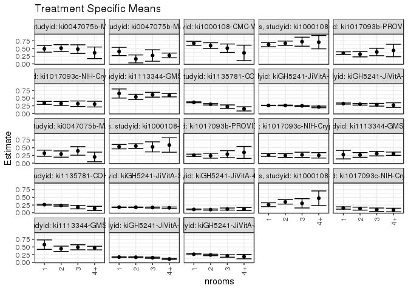

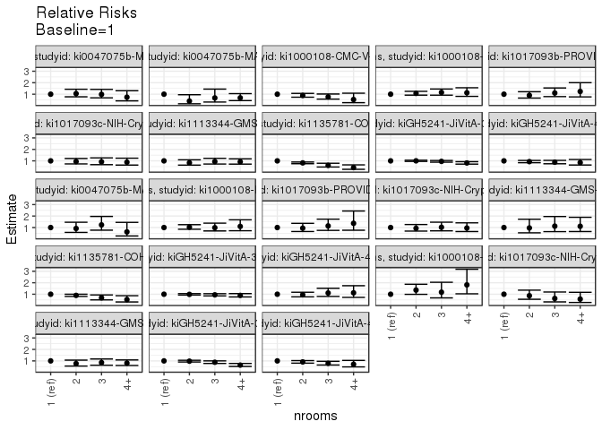

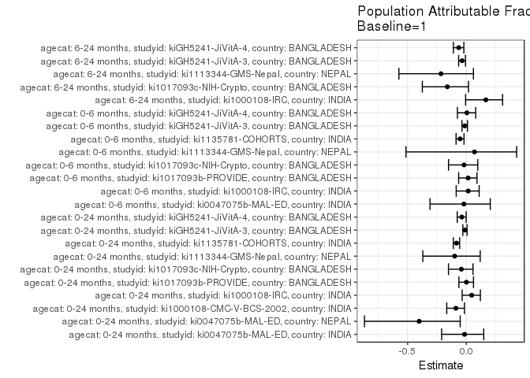

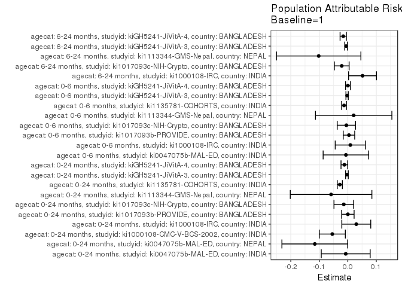

## Results Table

### Parameter: TSM

| agecat | studyid | country | intervention_level | baseline_level | estimate | ci_lower | ci_upper |
| --- | --- | --- | --- | --- | --- | --- | --- |
| 0-24 months | ki0047075b-MAL-ED | INDIA | 1 | NA | 0.4880952 | 0.3809726 | 0.5952179 |
| 0-24 months | ki0047075b-MAL-ED | INDIA | 2 | NA | 0.5128205 | 0.4016591 | 0.6239819 |
| 0-24 months | ki0047075b-MAL-ED | INDIA | 3 | NA | 0.4791667 | 0.3375396 | 0.6207937 |
| 0-24 months | ki0047075b-MAL-ED | INDIA | 4+ | NA | 0.3600000 | 0.1714418 | 0.5485582 |
| 0-24 months | ki0047075b-MAL-ED | NEPAL | 1 | NA | 0.4038462 | 0.2702003 | 0.5374921 |
| 0-24 months | ki0047075b-MAL-ED | NEPAL | 2 | NA | 0.1612903 | 0.0315427 | 0.2910379 |
| 0-24 months | ki0047075b-MAL-ED | NEPAL | 3 | NA | 0.2727273 | 0.0862303 | 0.4592242 |
| 0-24 months | ki0047075b-MAL-ED | NEPAL | 4+ | NA | 0.2748092 | 0.1982008 | 0.3514175 |
| 0-24 months | ki1000108-CMC-V-BCS-2002 | INDIA | 1 | NA | 0.6683168 | 0.6033026 | 0.7333310 |
| 0-24 months | ki1000108-CMC-V-BCS-2002 | INDIA | 2 | NA | 0.5943396 | 0.5007394 | 0.6879398 |
| 0-24 months | ki1000108-CMC-V-BCS-2002 | INDIA | 3 | NA | 0.5098039 | 0.3724211 | 0.6471867 |
| 0-24 months | ki1000108-CMC-V-BCS-2002 | INDIA | 4+ | NA | 0.3571429 | 0.1058123 | 0.6084734 |
| 0-24 months | ki1000108-IRC | INDIA | 1 | NA | 0.6270270 | 0.5572557 | 0.6967983 |
| 0-24 months | ki1000108-IRC | INDIA | 2 | NA | 0.6705882 | 0.5998500 | 0.7413264 |
| 0-24 months | ki1000108-IRC | INDIA | 3 | NA | 0.7222222 | 0.5757302 | 0.8687142 |
| 0-24 months | ki1000108-IRC | INDIA | 4+ | NA | 0.7058824 | 0.4890205 | 0.9227442 |
| 0-24 months | ki1017093b-PROVIDE | BANGLADESH | 1 | NA | 0.3510848 | 0.3095077 | 0.3926619 |
| 0-24 months | ki1017093b-PROVIDE | BANGLADESH | 2 | NA | 0.3148148 | 0.2271595 | 0.4024701 |
| 0-24 months | ki1017093b-PROVIDE | BANGLADESH | 3 | NA | 0.3870968 | 0.2657667 | 0.5084268 |
| 0-24 months | ki1017093b-PROVIDE | BANGLADESH | 4+ | NA | 0.4347826 | 0.2320431 | 0.6375221 |
| 0-24 months | ki1017093c-NIH-Crypto | BANGLADESH | 1 | NA | 0.3451087 | 0.2965045 | 0.3937129 |
| 0-24 months | ki1017093c-NIH-Crypto | BANGLADESH | 2 | NA | 0.3246073 | 0.2581603 | 0.3910543 |
| 0-24 months | ki1017093c-NIH-Crypto | BANGLADESH | 3 | NA | 0.3173077 | 0.2277978 | 0.4068176 |
| 0-24 months | ki1017093c-NIH-Crypto | BANGLADESH | 4+ | NA | 0.3052632 | 0.2125972 | 0.3979291 |
| 0-24 months | ki1113344-GMS-Nepal | NEPAL | 1 | NA | 0.6500000 | 0.5020654 | 0.7979346 |
| 0-24 months | ki1113344-GMS-Nepal | NEPAL | 2 | NA | 0.5390625 | 0.4526364 | 0.6254886 |
| 0-24 months | ki1113344-GMS-Nepal | NEPAL | 3 | NA | 0.6107383 | 0.5323837 | 0.6890928 |
| 0-24 months | ki1113344-GMS-Nepal | NEPAL | 4+ | NA | 0.5964912 | 0.5394859 | 0.6534965 |
| 0-24 months | ki1135781-COHORTS | INDIA | 1 | NA | 0.3634292 | 0.3475179 | 0.3793406 |
| 0-24 months | ki1135781-COHORTS | INDIA | 2 | NA | 0.2992278 | 0.2764584 | 0.3219972 |

[output cut: 62 more lines]

### Parameter: E(Y)

| agecat | studyid | country | intervention_level | baseline_level | estimate | ci_lower | ci_upper |
| --- | --- | --- | --- | --- | --- | --- | --- |
| 0-24 months | ki0047075b-MAL-ED | INDIA | NA | NA | 0.4808511 | 0.4168346 | 0.5448675 |
| 0-24 months | ki0047075b-MAL-ED | NEPAL | NA | NA | 0.2881356 | 0.2302312 | 0.3460400 |
| 0-24 months | ki1000108-CMC-V-BCS-2002 | INDIA | NA | NA | 0.6139410 | 0.5644682 | 0.6634139 |
| 0-24 months | ki1000108-IRC | INDIA | NA | NA | 0.6568627 | 0.6107393 | 0.7029862 |
| 0-24 months | ki1017093b-PROVIDE | BANGLADESH | NA | NA | 0.3514286 | 0.3160364 | 0.3868207 |
| 0-24 months | ki1017093c-NIH-Crypto | BANGLADESH | NA | NA | 0.3311346 | 0.2976093 | 0.3646598 |
| 0-24 months | ki1113344-GMS-Nepal | NEPAL | NA | NA | 0.5913621 | 0.5520608 | 0.6306634 |
| 0-24 months | ki1135781-COHORTS | INDIA | NA | NA | 0.3354454 | 0.3228114 | 0.3480794 |
| 0-24 months | kiGH5241-JiVitA-3 | BANGLADESH | NA | NA | 0.2580394 | 0.2515717 | 0.2645070 |
| 0-24 months | kiGH5241-JiVitA-4 | BANGLADESH | NA | NA | 0.3101161 | 0.2957091 | 0.3245231 |
| 0-6 months | ki0047075b-MAL-ED | INDIA | NA | NA | 0.3148936 | 0.2553821 | 0.3744051 |
| 0-6 months | ki1000108-IRC | INDIA | NA | NA | 0.5441176 | 0.4957312 | 0.5925041 |
| 0-6 months | ki1017093b-PROVIDE | BANGLADESH | NA | NA | 0.2585714 | 0.2261125 | 0.2910304 |
| 0-6 months | ki1017093c-NIH-Crypto | BANGLADESH | NA | NA | 0.2585752 | 0.2273844 | 0.2897660 |
| 0-6 months | ki1113344-GMS-Nepal | NEPAL | NA | NA | 0.2956811 | 0.2591967 | 0.3321655 |
| 0-6 months | ki1135781-COHORTS | INDIA | NA | NA | 0.2494186 | 0.2376119 | 0.2612253 |
| 0-6 months | kiGH5241-JiVitA-3 | BANGLADESH | NA | NA | 0.1763127 | 0.1706830 | 0.1819425 |
| 0-6 months | kiGH5241-JiVitA-4 | BANGLADESH | NA | NA | 0.1078103 | 0.0979895 | 0.1176312 |
| 6-24 months | ki1000108-IRC | INDIA | NA | NA | 0.3112745 | 0.2662918 | 0.3562572 |
| 6-24 months | ki1017093c-NIH-Crypto | BANGLADESH | NA | NA | 0.1315069 | 0.1069744 | 0.1560393 |
| 6-24 months | ki1113344-GMS-Nepal | NEPAL | NA | NA | 0.4728814 | 0.4325613 | 0.5132014 |
| 6-24 months | kiGH5241-JiVitA-3 | BANGLADESH | NA | NA | 0.1637742 | 0.1576516 | 0.1698967 |
| 6-24 months | kiGH5241-JiVitA-4 | BANGLADESH | NA | NA | 0.2472801 | 0.2337480 | 0.2608122 |

### Parameter: RR

| agecat | studyid | country | intervention_level | baseline_level | estimate | ci_lower | ci_upper |
| --- | --- | --- | --- | --- | --- | --- | --- |
| 0-24 months | ki0047075b-MAL-ED | INDIA | 1 | 1 | 1.0000000 | 1.0000000 | 1.0000000 |
| 0-24 months | ki0047075b-MAL-ED | INDIA | 2 | 1 | 1.0506567 | 0.7717801 | 1.4303031 |
| 0-24 months | ki0047075b-MAL-ED | INDIA | 3 | 1 | 0.9817073 | 0.6793598 | 1.4186138 |
| 0-24 months | ki0047075b-MAL-ED | INDIA | 4+ | 1 | 0.7375610 | 0.4179882 | 1.3014629 |
| 0-24 months | ki0047075b-MAL-ED | NEPAL | 1 | 1 | 1.0000000 | 1.0000000 | 1.0000000 |
| 0-24 months | ki0047075b-MAL-ED | NEPAL | 2 | 1 | 0.3993856 | 0.1673490 | 0.9531510 |
| 0-24 months | ki0047075b-MAL-ED | NEPAL | 3 | 1 | 0.6753247 | 0.3159245 | 1.4435834 |
| 0-24 months | ki0047075b-MAL-ED | NEPAL | 4+ | 1 | 0.6804798 | 0.4414650 | 1.0489004 |
| 0-24 months | ki1000108-CMC-V-BCS-2002 | INDIA | 1 | 1 | 1.0000000 | 1.0000000 | 1.0000000 |
| 0-24 months | ki1000108-CMC-V-BCS-2002 | INDIA | 2 | 1 | 0.8893082 | 0.7390273 | 1.0701487 |
| 0-24 months | ki1000108-CMC-V-BCS-2002 | INDIA | 3 | 1 | 0.7628177 | 0.5727883 | 1.0158916 |
| 0-24 months | ki1000108-CMC-V-BCS-2002 | INDIA | 4+ | 1 | 0.5343915 | 0.2626208 | 1.0874016 |
| 0-24 months | ki1000108-IRC | INDIA | 1 | 1 | 1.0000000 | 1.0000000 | 1.0000000 |
| 0-24 months | ki1000108-IRC | INDIA | 2 | 1 | 1.0694726 | 0.9174461 | 1.2466909 |
| 0-24 months | ki1000108-IRC | INDIA | 3 | 1 | 1.1518199 | 0.9139231 | 1.4516420 |
| 0-24 months | ki1000108-IRC | INDIA | 4+ | 1 | 1.1257606 | 0.8119695 | 1.5608184 |
| 0-24 months | ki1017093b-PROVIDE | BANGLADESH | 1 | 1 | 1.0000000 | 1.0000000 | 1.0000000 |
| 0-24 months | ki1017093b-PROVIDE | BANGLADESH | 2 | 1 | 0.8966916 | 0.6625787 | 1.2135250 |
| 0-24 months | ki1017093b-PROVIDE | BANGLADESH | 3 | 1 | 1.1025734 | 0.7886639 | 1.5414274 |
| 0-24 months | ki1017093b-PROVIDE | BANGLADESH | 4+ | 1 | 1.2383977 | 0.7654544 | 2.0035533 |
| 0-24 months | ki1017093c-NIH-Crypto | BANGLADESH | 1 | 1 | 1.0000000 | 1.0000000 | 1.0000000 |
| 0-24 months | ki1017093c-NIH-Crypto | BANGLADESH | 2 | 1 | 0.9405945 | 0.7336577 | 1.2059001 |
| 0-24 months | ki1017093c-NIH-Crypto | BANGLADESH | 3 | 1 | 0.9194428 | 0.6708013 | 1.2602465 |
| 0-24 months | ki1017093c-NIH-Crypto | BANGLADESH | 4+ | 1 | 0.8845421 | 0.6329740 | 1.2360928 |
| 0-24 months | ki1113344-GMS-Nepal | NEPAL | 1 | 1 | 1.0000000 | 1.0000000 | 1.0000000 |
| 0-24 months | ki1113344-GMS-Nepal | NEPAL | 2 | 1 | 0.8293269 | 0.6277999 | 1.0955451 |
| 0-24 months | ki1113344-GMS-Nepal | NEPAL | 3 | 1 | 0.9395973 | 0.7235647 | 1.2201302 |
| 0-24 months | ki1113344-GMS-Nepal | NEPAL | 4+ | 1 | 0.9176788 | 0.7169492 | 1.1746081 |
| 0-24 months | ki1135781-COHORTS | INDIA | 1 | 1 | 1.0000000 | 1.0000000 | 1.0000000 |
| 0-24 months | ki1135781-COHORTS | INDIA | 2 | 1 | 0.8233455 | 0.7541459 | 0.8988947 |

[output cut: 62 more lines]

### Parameter: PAR

| agecat | studyid | country | intervention_level | baseline_level | estimate | ci_lower | ci_upper |
| --- | --- | --- | --- | --- | --- | --- | --- |
| 0-24 months | ki0047075b-MAL-ED | INDIA | 1 | NA | -0.0072442 | -0.0930916 | 0.0786032 |
| 0-24 months | ki0047075b-MAL-ED | NEPAL | 1 | NA | -0.1157106 | -0.2312229 | -0.0001983 |
| 0-24 months | ki1000108-CMC-V-BCS-2002 | INDIA | 1 | NA | -0.0543758 | -0.1001608 | -0.0085908 |
| 0-24 months | ki1000108-IRC | INDIA | 1 | NA | 0.0298357 | -0.0209656 | 0.0806370 |
| 0-24 months | ki1017093b-PROVIDE | BANGLADESH | 1 | NA | 0.0003438 | -0.0215006 | 0.0221882 |
| 0-24 months | ki1017093c-NIH-Crypto | BANGLADESH | 1 | NA | -0.0139741 | -0.0485068 | 0.0205585 |
| 0-24 months | ki1113344-GMS-Nepal | NEPAL | 1 | NA | -0.0586379 | -0.2018893 | 0.0846136 |
| 0-24 months | ki1135781-COHORTS | INDIA | 1 | NA | -0.0279838 | -0.0370108 | -0.0189569 |
| 0-24 months | kiGH5241-JiVitA-3 | BANGLADESH | 1 | NA | -0.0029202 | -0.0075965 | 0.0017562 |
| 0-24 months | kiGH5241-JiVitA-4 | BANGLADESH | 1 | NA | -0.0119391 | -0.0237656 | -0.0001125 |
| 0-6 months | ki0047075b-MAL-ED | INDIA | 1 | NA | -0.0065350 | -0.0865200 | 0.0734501 |
| 0-6 months | ki1000108-IRC | INDIA | 1 | NA | 0.0089825 | -0.0441544 | 0.0621194 |
| 0-6 months | ki1017093b-PROVIDE | BANGLADESH | 1 | NA | 0.0041336 | -0.0160635 | 0.0243306 |
| 0-6 months | ki1017093c-NIH-Crypto | BANGLADESH | 1 | NA | -0.0050118 | -0.0371327 | 0.0271092 |
| 0-6 months | ki1113344-GMS-Nepal | NEPAL | 1 | NA | 0.0206811 | -0.1133395 | 0.1547017 |
| 0-6 months | ki1135781-COHORTS | INDIA | 1 | NA | -0.0131628 | -0.0216054 | -0.0047202 |
| 0-6 months | kiGH5241-JiVitA-3 | BANGLADESH | 1 | NA | -0.0023553 | -0.0064724 | 0.0017619 |
| 0-6 months | kiGH5241-JiVitA-4 | BANGLADESH | 1 | NA | 0.0005601 | -0.0078309 | 0.0089511 |
| 6-24 months | ki1000108-IRC | INDIA | 1 | NA | 0.0518151 | 0.0028666 | 0.1007635 |
| 6-24 months | ki1017093c-NIH-Crypto | BANGLADESH | 1 | NA | -0.0212309 | -0.0471652 | 0.0047034 |
| 6-24 months | ki1113344-GMS-Nepal | NEPAL | 1 | NA | -0.1021186 | -0.2502633 | 0.0460260 |
| 6-24 months | kiGH5241-JiVitA-3 | BANGLADESH | 1 | NA | -0.0058579 | -0.0106007 | -0.0011150 |
| 6-24 months | kiGH5241-JiVitA-4 | BANGLADESH | 1 | NA | -0.0159603 | -0.0270561 | -0.0048644 |

### Parameter: PAF

| agecat | studyid | country | intervention_level | baseline_level | estimate | ci_lower | ci_upper |
| --- | --- | --- | --- | --- | --- | --- | --- |
| 0-24 months | ki0047075b-MAL-ED | INDIA | 1 | NA | -0.0150653 | -0.2102721 | 0.1486562 |
| 0-24 months | ki0047075b-MAL-ED | NEPAL | 1 | NA | -0.4015837 | -0.8671485 | -0.0521053 |
| 0-24 months | ki1000108-CMC-V-BCS-2002 | INDIA | 1 | NA | -0.0885685 | -0.1666538 | -0.0157095 |
| 0-24 months | ki1000108-IRC | INDIA | 1 | NA | 0.0454215 | -0.0353262 | 0.1198716 |
| 0-24 months | ki1017093b-PROVIDE | BANGLADESH | 1 | NA | 0.0009782 | -0.0631552 | 0.0612428 |
| 0-24 months | ki1017093c-NIH-Crypto | BANGLADESH | 1 | NA | -0.0422008 | -0.1518858 | 0.0570399 |
| 0-24 months | ki1113344-GMS-Nepal | NEPAL | 1 | NA | -0.0991573 | -0.3704080 | 0.1184036 |
| 0-24 months | ki1135781-COHORTS | INDIA | 1 | NA | -0.0834229 | -0.1106879 | -0.0568272 |
| 0-24 months | kiGH5241-JiVitA-3 | BANGLADESH | 1 | NA | -0.0113168 | -0.0295990 | 0.0066407 |
| 0-24 months | kiGH5241-JiVitA-4 | BANGLADESH | 1 | NA | -0.0384987 | -0.0772864 | -0.0011075 |
| 0-6 months | ki0047075b-MAL-ED | INDIA | 1 | NA | -0.0207529 | -0.3091538 | 0.2041146 |
| 0-6 months | ki1000108-IRC | INDIA | 1 | NA | 0.0165084 | -0.0861781 | 0.1094870 |
| 0-6 months | ki1017093b-PROVIDE | BANGLADESH | 1 | NA | 0.0159861 | -0.0652990 | 0.0910690 |
| 0-6 months | ki1017093c-NIH-Crypto | BANGLADESH | 1 | NA | -0.0193822 | -0.1514839 | 0.0975644 |
| 0-6 months | ki1113344-GMS-Nepal | NEPAL | 1 | NA | 0.0699438 | -0.5140951 | 0.4286987 |
| 0-6 months | ki1135781-COHORTS | INDIA | 1 | NA | -0.0527739 | -0.0871444 | -0.0194901 |
| 0-6 months | kiGH5241-JiVitA-3 | BANGLADESH | 1 | NA | -0.0133584 | -0.0369751 | 0.0097204 |
| 0-6 months | kiGH5241-JiVitA-4 | BANGLADESH | 1 | NA | 0.0051952 | -0.0757200 | 0.0800240 |
| 6-24 months | ki1000108-IRC | INDIA | 1 | NA | 0.1664609 | -0.0060540 | 0.3093936 |
| 6-24 months | ki1017093c-NIH-Crypto | BANGLADESH | 1 | NA | -0.1614433 | -0.3746120 | 0.0186681 |
| 6-24 months | ki1113344-GMS-Nepal | NEPAL | 1 | NA | -0.2159498 | -0.5741157 | 0.0607209 |
| 6-24 months | kiGH5241-JiVitA-3 | BANGLADESH | 1 | NA | -0.0357680 | -0.0651349 | -0.0072108 |
| 6-24 months | kiGH5241-JiVitA-4 | BANGLADESH | 1 | NA | -0.0645432 | -0.1101779 | -0.0207844 |